# Informe Descriptivo Estudio MARES

# Presentación

La investigación llevada a cabo durante la asignatura de **Tècniques de Recerca** ha permitido evaluar la motivación académica, el absentismo y el rendimiento percibido a lo largo de un semestre. Para ello, se hicieron 14 recogidas de datos a lo largo del periodo comprendido entre los meses de septiembre y diciembre. En cada una de estas ocasiones, se aplicó un cuestionario que contenía información sobre motivación intrínseca, motivación extrínseca, amotivación, absentismo y rendimiento percibido.

En la **motivación intrínseca** la regulación de la persona es completamente interna, estando el comportamiento motivado por la mera satisfacción de hacer una actividad y el disfrute inherente a esta actividad (*“Lo hago porque las actividades son interesantes”*).

En la motivación extrínseca el grado de la regulación de la persona puede variar. La forma de motivación extrínseca cuyo grado de regulación es más interno es la **regulación identificada**, referida al hecho de realizar una actividad porque sus objetivos son congruentes con los objetivos personales del individuo (*“Lo hago porque poner esfuerzo en estas actividades se alinea con mis valores personales”*). La siguiente, denominada **regulación introyectada**, es interna a la persona aunque ésta no ha sido aceptada como propia; el hecho de involucrarse en una actividad se debe a sentimientos como la culpa y la obligación o, incluso, el hecho de mantener la autoestima (*“Lo hago porque de lo contrario podría sentirme avergonzado de mí mismo/a”*). La **regulación externa**, referida a la realización de una tarea para obtener recompensas o evitar castigos, es la forma menos autónoma de motivación extrínseca. La regulación externa puede presentar dos facetas: **Material** (*“Lo hago porque quiero conseguir una buena nota”*) y **Social** (*“Lo hago para evitar ser criticado por los demás”*).

Finalmente, aquellos estados en los que la motivación no aparece se definen como **amotivación**.

Los objetivos de la investigación fueron: Por un lado conocer cómo evolucionan distintas formas de motivación académica a lo largo de un semestre; por otro, conocer cómo y cuánto influye la motivación en los posteriores resultados académicos. Además, nos interesaba saber la evolución del absentismo, sus causas y su impacto sobre el rendimiento académico.

A continuación te presentamos los principales resultados descriptivos encontrados hasta el momento. En este informe podrás encontrar resultados a nivel de toda la muestra y también algunos resultados referidos a tu persona.

# Variables medidas

Para medir diferentes formas de motivación académica: motivación intrínseca, regulación identificada, regulación introyectada, regulación externa (social y material), y amotivación; se ha utilizado la **Escala Multidimensional de Motivación Académica** (EMMA, Navarro et al., 2024), versión adaptada del MWMS de Gagné et al. (2015).

Para evaluar el absentismo utilizamos una pregunta sobre su frecuencia en el cuestionario semanal así como un cuestionario sobre causas de absentismo (Triadó-Ivern et al., 2013). Este cuestionario incluye 5 factores relacionados con las causas del absentismo: planificación del estudiantado (p.ej. *Estoy cursando simultáneamente otro grado*), metodología docente (p. ej. *Debido al profesorado, las sesiones son muy pesadas y/o aburridas*), metodología de aprendizaje (p. ej. *Tengo acceso a los apuntes por lo que no asisto a las sesiones de la asignatura*), factores relacionados con el curso (p. ej. *El contenido es muy simple*) y fuentes externas disponibles (p. ej. *Es mejor asistir a academias en las que te preparan para aprobar los exámenes de la asignatura* ).

# Resultados

## 1) Descripción de la motivación en la muestra de participantes

|  | Media | DT | Mediana | Mínimo | Máximo |
| --- | --- | --- | --- | --- | --- |
| Motivación Intrínseca | 2.96 | 1.28 | 3.01 | 1.07 | 5.86 |
| Regulación Identificada | 4.34 | 1.49 | 4.14 | 1.55 | 7.00 |
| Regulación Introyectada | 4.49 | 1.39 | 4.64 | 1.48 | 6.93 |
| Regulación Externa (social) | 2.56 | 1.25 | 2.45 | 1.00 | 6.45 |
| Regulación Externa (material) | 6.08 | 0.92 | 6.26 | 2.50 | 7.00 |
| Amotivación | 1.97 | 1.01 | 1.60 | 1.00 | 5.64 |

<sup>1</sup> No de participantes: 51 alumnas/os

## 2) Evolución de los diferentes tipos de motivación a lo largo del semestre

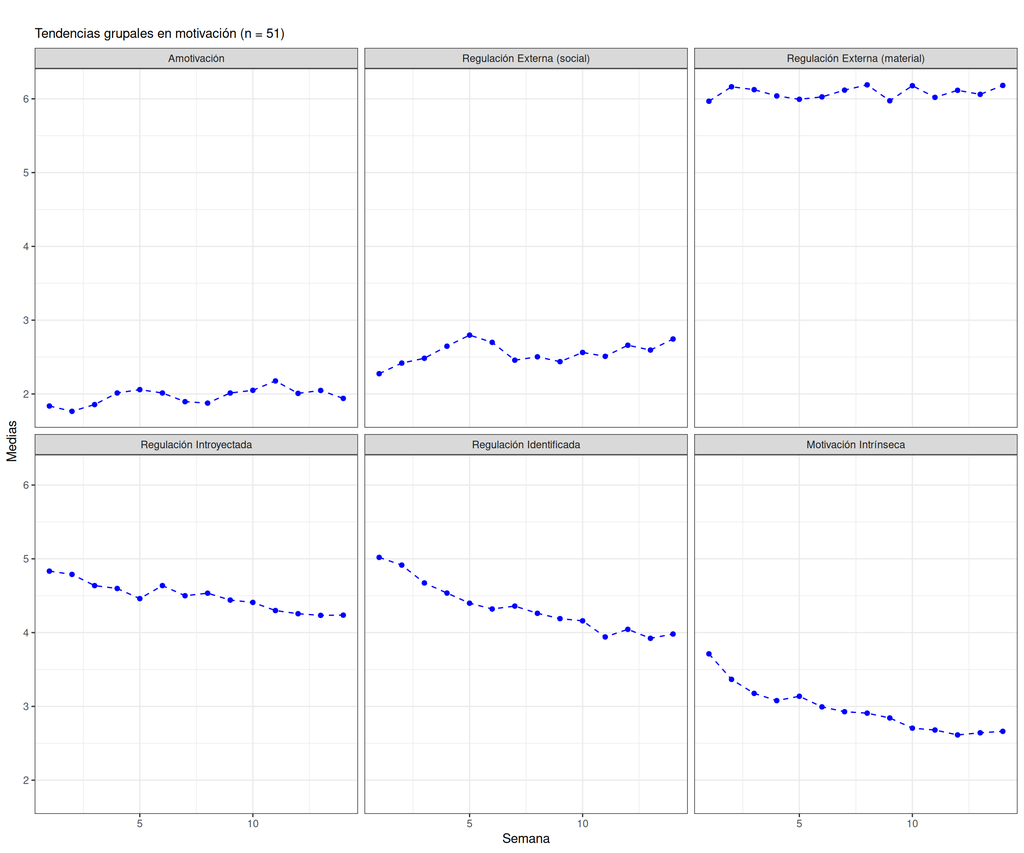

Un total de 51 alumnos participaron en el estudio a lo largo del semestre. La variable cuya puntuación media resultó más alta, fue **Regulación Externa (material)**. Por el contrario, en la variable **Amotivación** se obtuvo una puntuación media más baja. En todas las dimensiones las puntuaciones pueden variar de 1 a 7 puntos (a mayor puntuación promedio mayor importancia se espera que tenga esa dimensión).

Las diferentes formas de motivación se han evaluado teniendo en cuenta únicamente a las personas que participaron en al menos 10 ocasiones. Se han observado evoluciones distintas de estas variables a lo largo del semestre:

*Amotivación* - Tendencia creciente.

*Regulación externa (social)* - Tendencia creciente.

*Regulación externa (material)* - No se han observado cambios significativos.

*Regulación introyectada* - Tendencia decreciente.

*Regulación identificada* - Tendencia decreciente.

*Motivación intrínseca* - Tendencia decreciente.

## 3) ¿Cómo fue tu motivación durante el semestre?

En el siguiente gráfico se comparan las tendencias globales (en azul) con tu tendencia individual (en verde).

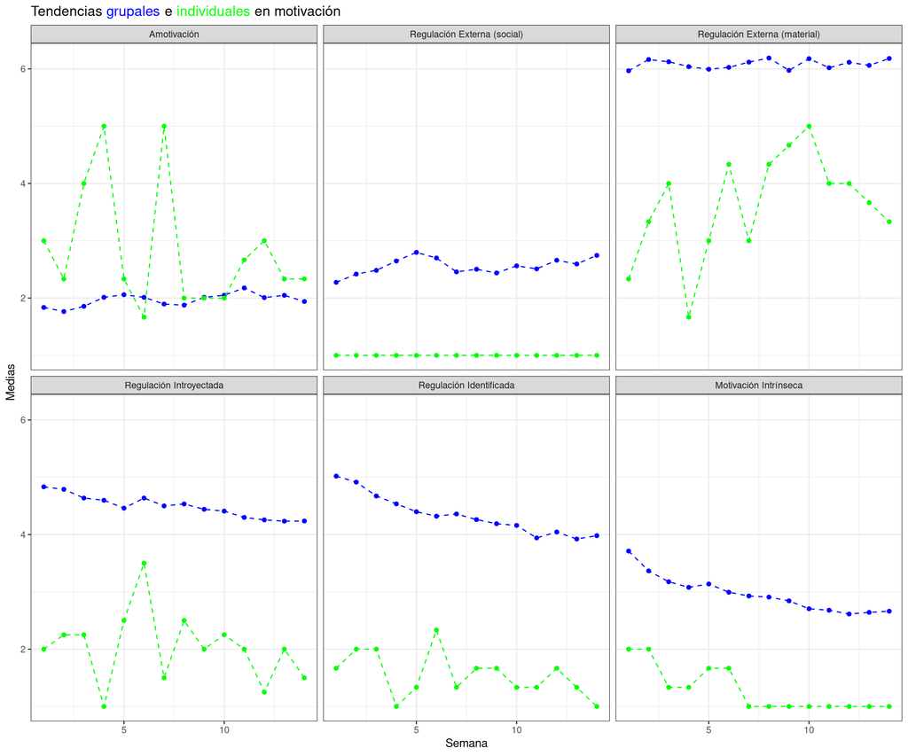

Estudiando ahora la evolución de estas variables a lo largo del semestre en tu caso particular, podemos extraer las siguientes conclusiones:

*Amotivación* - No se han observado cambios significativos.

*Regulación externa (social)* - No se han observado cambios significativos.

*Regulación externa (material)* - No se han observado cambios significativos.

*Regulación introyectada* - No se han observado cambios significativos.

*Regulación identificada* - No se han observado cambios significativos.

*Motivación intrínseca* - Tendencia decreciente.

Podemos representar tus valores promedio en los distintos tipos de motivación en estas 14 semanas. El código de color te ayudará a saber qué tipos de motivación pueden mejorar de forma orientativa, éstos se han determinado sobre el máximo en cada una de las escalas.

[interactive chart not shown]

Ten en cuenta que interesa obtener puntuaciones bajas en amotivación y que tu perfil se acerque lo máximo posible a una modalidad intrínseca.

## 4) Análisis descriptivo del absentismo

En el siguiente gráfico se comparan las horas acumuladas promedio de todo el grupo de participantes (en azul) con tu acumulado a lo largo del curso (en verde).

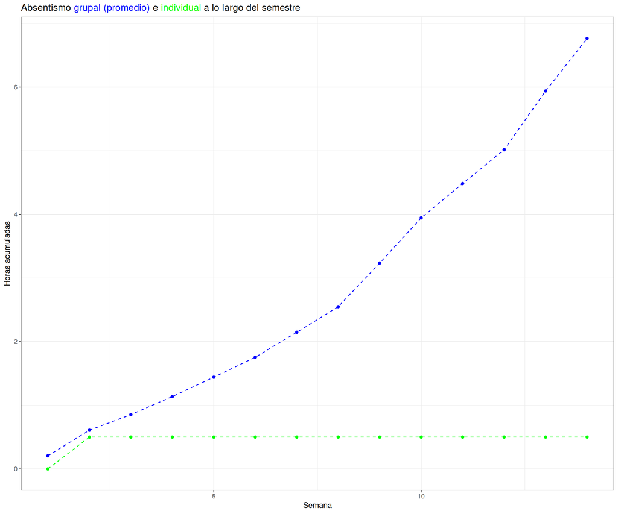

[output not shown]

<sup>1</sup> No de participantes: 51 alumnas/os

Finalmente, te mostramos la evolución de las puntuaciones promedio en los factores relacionados con el absentismo a nivel del grupo de participantes en el estudio (en azul) y tu evolución individual a lo largo del estudio (en verde, en caso de que se haya recogido información en tu encuesta semanal a propósito de estas causas de absentismo). Recuerda que las puntuaciones promedio en esos factores pueden tomar valores de 1 a 5 (siendo una puntuación mayor signo de mayor importancia del factor como causa del absentismo).

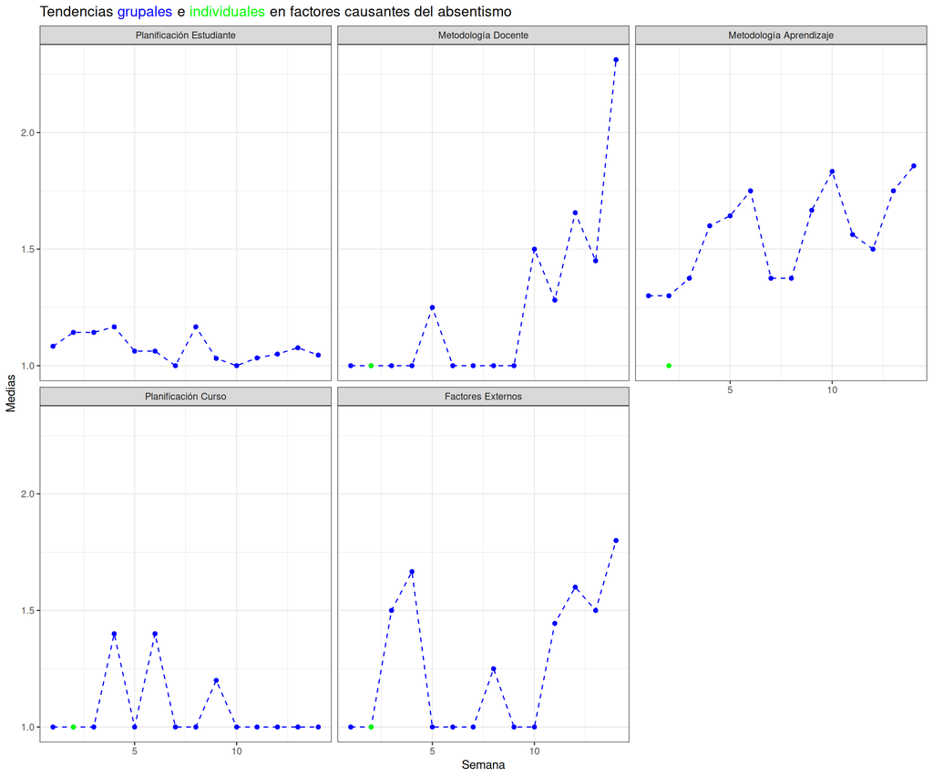

## 5) Análisis del rendimiento académico

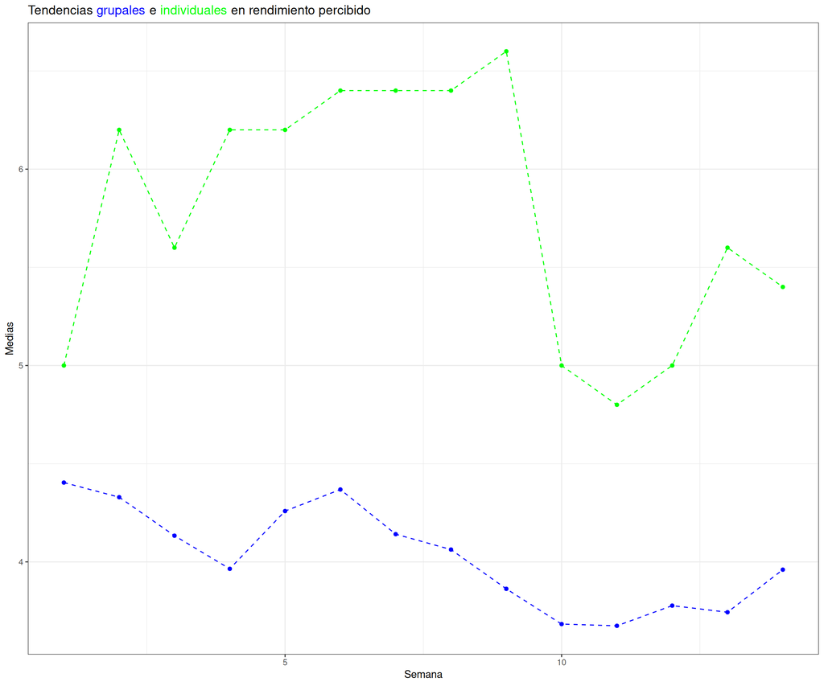

En cuanto al rendimiento objetivo, contamos con algunas de las calificaciones finales en la asignatura de “Tècniques de Recerca”. El gráfico se muestra la distribución de estas notas y en verde (si contamos con ella) tu calificación final:

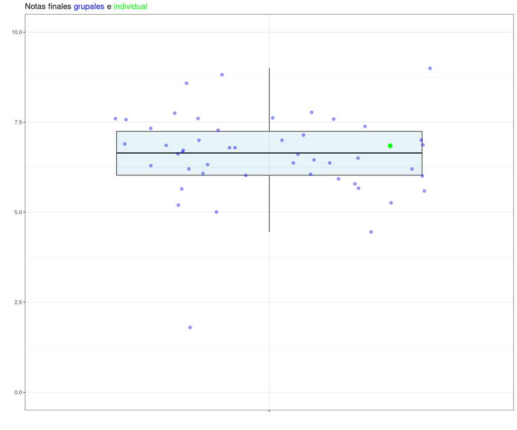

## 6) Algunas conclusiones preliminares

- Se observan 2 grupos bien diferenciados en cuanto a motivación en el curso: uno más amotivado y otro más motivado intrínsecamente.
- El grupo más amotivado presenta una tasa mayor de absentismo que el grupo más motivado intrínsecamente (casi 6 horas más de ausencias en promedio).
- El grupo más motivado intrínsecamente percibe mayor rendimiento subjetivo que el grupo más amotivado (1,3 puntos más en promedio).
- El grupo más motivado intrínsecamente obtiene 0,3 puntos más en la nota final que el grupo más amotivado.

## *Aprovechamos para agradecerte tu participación. Nos es de gran utilidad para conoceros mejor y poder planificar acciones de mejora docente en el futuro. Finalmente, recuerda que por haber participado entrarás en un sorteo de tres premios de 150€ que se llevará a cabo entre todos los participantes que completen el estudio al finalizar la recogida de datos, en el próximo mes de julio.*

# Referencias

Gagné, M., Forest, J., Vansteenkiste, M., Crevier-Braud, L., Van den Broeck, A., Aspeli, A. K., … & Halvari, H. (2015). The Multidimensional Work Motivation Scale: Validation evidence in seven languages and nine countries. *European Journal of Work and Organizational Psychology*, *24*(2), 178-196.

Navarro, J., Wietrak, E., & Leiva, D. (2024). *Escala Multidimensional de Motivación Académica*. Documento de trabajo. Universitat de Barcelona.

Triadó-Ivern, X. M., Aparicio-Chueca, P., Guàrdia-Olmos, J., Peró-Cebollero, M., & Jaría-Chacón, N. (2013). Empirical approach to the analysis of university student absenteeism: Proposal of a questionnaire for students to evaluate the possible causes. *Quality & Quantity*, *47*, 2281–2288. https://doi.org/10.1007/s11135-011-9654-3